# Learning R Markdown Biodiversity

Pelle S. van Hilst

28/March/2024

Code in text does not run. There are visual effects like *italic* or **bold**.

You can also make a

# Header

or a smaller

## Header

Markdown is useful for:

- Creating order in your code
- Sharing your code

You could rank these points by importance:

1. Sharing you code
2. Creating order in your code

This all makes [this](https://ourcodingclub.github.io/tutorials/rmarkdown/) tutorial very useful

You could say R markdown is as beautiful as the most beautiful equation

$e^{\pi \times i} + 1 = 0$

Just an example of how to show R code. Starting R code can be done with the green C button at the top.

```r
norm <- rnorm(100, mean = 0, sd = 1)
```

You can do stuff but not show the code in the document by using `r, echo = FALSE`.

```
##   A  B
## 1 a  5
## 2 a 10
## 3 b 15
## 4 b 20
```

```
## [1] "see?"
```

You can do stuff but not show anything in the document by using `r, include = FALSE`.

```r
setwd("D:/Master_thesis/How_to_unix_R/Learn_R_Markdown/CC-2-RMarkdown-master")
edidiv <- read.csv("edidiv.csv")
```

Of course you need to load packages, **before** you use them. R Markdown runs everything in order separately.

```r
library(dplyr)
```

```r
richness <-
  edidiv |>
    group_by(taxonGroup) |>
    summarise(Species_richness = n_distinct(taxonName))
```

Making simple tables is easier with knitr

```r
library(knitr)
kable(dataframe, digits = 2)
```

| A | B |
| --- | --- |
| a | 5 |
| a | 10 |
| b | 15 |
| b | 20 |

More control over table with pander package and just better in general

```r
library(pander)
plant <- c("a", "b", "c")
temperature <- c(20, 20, 20)
growth <- c(0.65, 0.95, 0.15)
dataframe <- data.frame(plant, temperature, growth)
emphasize.italics.cols(3)   # Make the 3rd column italics
pander(dataframe)           # Create the table
```

| plant | temperature | growth |
| --- | --- | --- |
| a | 20 | *0.65* |
| b | 20 | *0.95* |
| c | 20 | *0.15* |

```r
A <- c("a", "a", "b", "b")
B <- c(5, 10, 15, 20)
dataframe <- data.frame(A, B)
pander(dataframe, digits = 2)
```

| A | B |
| --- | --- |
| a | 5 |
| a | 10 |
| b | 15 |
| b | 20 |

You can make a table using markdown syntax. I don’t think they look as good though.

| Plant | Temp. | Growth |
| --- | --- | --- |
| A | 20 | 0.65 |
| B | 20 | 0.95 |
| C | 20 | 0.15 |

Using tidy() from the package broom, we are able to create tables of our model outputs.

```r
library(broom)
library(pander)
A <- c(20, 15, 10)
B <- c(1, 2, 3)

lm_test <- lm(A ~ B)            # Creating linear model

table_obj <- tidy(lm_test)      # Using tidy() to create a new R object called table

pander(table_obj, digits = 3)   # Using pander() to view the created table, with 3 sig figs
```

| term | estimate | std.error | statistic | p.value |
| --- | --- | --- | --- | --- |
| (Intercept) | 25 | 4.07e-15 | 6.14e+15 | 1.04e-16 |
| B | -5 | 1.88e-15 | -2.65e+15 | 2.4e-16 |

Add figure using `{r, fig.width = 4, fig.height = 3}`.

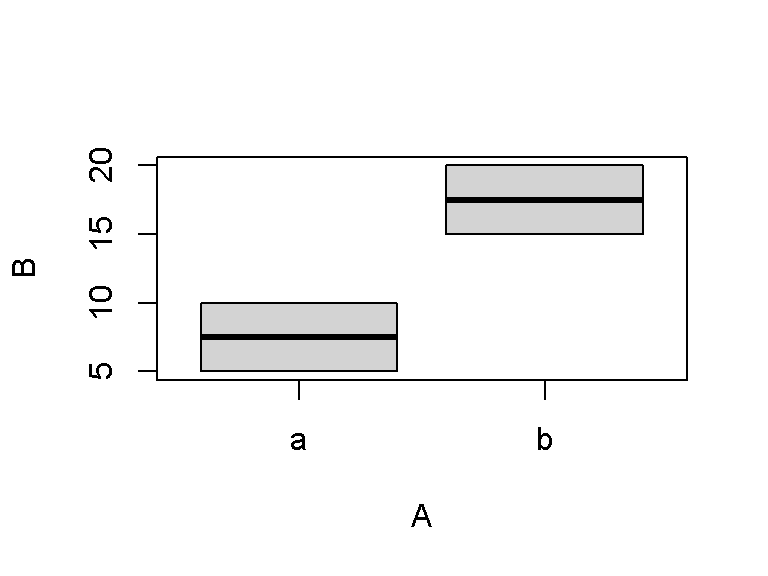

```r
A <- c("a", "a", "b", "b")
B <- c(5, 10, 15, 20)
dataframe <- data.frame(A, B)
boxplot(B~A,data=dataframe)
```